# MP10 与含铂治疗反应：首轮计算验证

生成时间：2026-11-09T23:08:51+08:00 (Asia/Shanghai)。分析配置于 **2026-11-09 21:44:39 +08:00** 冻结，早于任何评分关联分析。结果目录：`/home/data/t070721/codex_workspace/Bladder Metabolism/results/mp10_resistance_validation_v1`。

**当前结论：可执行分析没有形成“MP10 普遍对应顺铂耐药”的一致证据。**五种细胞系的 CisR 效应为2升3降；GSE212810 病理主终点 OR 约0.58，95% CI跨1；GSE169455 方案未核实的 NAC 补充结果也未显示较差反应关联。Epi 的 UP 和 DN 多数同为正相关，其中 DN 与预期耐药方向相反。阴性或不一致结果不等于证明不存在作用。

这不是全部主分析均已完成的声明：**Epi 患者级独立推断、指定细胞周期调整、GSE169455 严格顺铂主分析仍有明确输入阻塞**。它们保留 NA/BLOCKED，没有以细胞数、推导患者编号或未知治疗方案补足。

## 1. 实际完成范围与证据层级

| module | status | unit | finding | evidence | limit |
| --- | --- | --- | --- | --- | --- |
| 01 Epi | PARTIAL / patient inference BLOCKED | 36 eligible tumor specimens; independent patient N unknown | UP median within-specimen rho=0.2516; DN=0.3187, DN opposite expected direction | transcriptional specimen association only; deterministic average-tie AUCell-like | No confirmed patient crosswalk; S.Score/G2M.Score unavailable |
| 02 GSE171537 | COMPLETED | 5 cell-line backgrounds,60 RNA measurements | CisR2 positive/3 negative; mean delta0.0433,95% bootstrap CI[-0.2083,0.2949],sign-test P1 | cell-model association; no consistent elevation | 3 passages per derivative,not independent inductions;5 backgrounds |
| 03 GSE212810 | COMPLETED with endpoint missingness | 39 matched;4 GCb excluded;35 cisplatin-coded;28 endpoint-evaluable | nonresponse OR0.5756 [0.2172,1.5255],P0.2667;7 endpoint unknown | pretreatment pathological-response association | small N; observational; author GP code interpreted in cisplatin context; no treatment-benefit prediction |
| 03 GSE169455 | PARTIAL / strict cisplatin BLOCKED | 149 expression;125 NAC +24 induction | 125 NAC regimen-unverified sensitivity OR0.7674 [0.5335,1.1040],P0.1537 | NAC pathological-response sensitivity association only | No individual regimen/cycle data; cannot designate strict cisplatin main |
| 04 integration | COMPLETED for available evidence | modules retained separately | No convergent evidence for a general MP10 cisplatin-resistance direction | exploratory conclusion | No causality,cholesterol flux or predictive-treatment-benefit claim |

没有重新运行 NMF，没有修改 MP10 Top20、优化阈值、训练分类器、预测 IC50、增加耐药 signature 或用生存替代疗效。外部队列分别预处理、评分和建模；未合并表达矩阵或做跨队列 ComBat，也没有用两个不可比人群合并 OR。

## 2. 输入、评分与预先冻结的规则

固定 Top20 (按原顺序)：`HMGCS1, MSMO1, INSIG1, FDFT1, SQLE, FDPS, IDI1, ACSS2, ELOVL5, LDLR, MVD, SCD, HMGCR, ACAT2, SLC20A1, ACSL3, ACSL1, ADIPOR2, MXD1, NPC1`。MP10可用基因至少16/20 (80%) 是本轮操作阈值，不是公认生物学界值。完整列表与参数见 config/frozen_v1.json；SHA-256：`a6a00ec034d4ee145fb3b55806843ec4f90555686338f24d79d2c33b53d64d53`。

| cohort | n_original | n_exact_or_alias | n_background | n_present | missing | preprocessing |
| --- | --- | --- | --- | --- | --- | --- |
| GSE171537 | 58884 | 37601 | 57327 | 20 | NA | TMM log2CPM prior.count=1 |
| GSE169455 | 13624 | 13546 | 13619 | 18 | IDI1;ACAT2 | author RMA quantile normalized ComBat; no re-log |
| GSE212810 | 25737 | 24586 | 24423 | 20 | NA | TMM log2CPM prior.count=1 |

GSE171537和GSE212810原始counts按基因符号合并后，采用edgeR TMM、log2 CPM (prior.count=1)。GSE169455已经过作者RMA、分位数归一化、批次校正和探针中位数合并，原值范围0.662–13.542；没有再次log或重新批次校正。它缺少IDI1、ACAT2，但18/20达到阈值。三队列均用GSVA ssGSEA (alpha=0.25，normalize=TRUE)，使用完整提供的表达基因背景；不是HVG或仅20个目标基因。ssGSEA归一化并不保证数值在0–1，各队列绝对值也不直接比较。

映射先保留作者/注释库精确SYMBOL，再采用org.Hs.eg.db唯一ALIAS；重复counts取和，重复已归一化表达取中位数；未映射背景保留原ID。完整逐基因映射、矩阵覆盖、检测率与软件注释版本均已保存。细胞表达为0没有被误作“基因不在矩阵”，也没有逐患者改变signature。

Epi复用已核实的Top20 **平均秩AUCell-like**：原RNA counts、90011基因、K=4501、ties取平均、归一化分母为Σ(K−j)。新增集合采用同一实现。它不是官方AUCell随机ties实现；原项目比较表已显示二者不同，本报告明确这个方法偏离。全部123699细胞重算Top20的最大误差为3.33×10⁻¹⁶。Epi和bulk ssGSEA的绝对值、阈值不能互换。

Tsunoda采用官方MSigDB现时快照及文件hash锁定，UP15、DN50映射基因 (DN网页53个原始accession映射50个symbol)。原文两张表核实了集合方向，以及C1S在T24和KK47模型中相反；没有机械按网页倒置的Exact source交换集合。INSIG1是MP10与UP共有成员。没有把UP−DN包装成临床耐药指数。

## 3. Epi：完成样本内转录关联，患者推断受阻

原分析对象为123699个Epi/既有上皮谱系细胞、57个样本、5个dataset。保留Epi命名，不将全体Epi称为恶性细胞。肿瘤来源42个样本101263细胞，按每样本≥50细胞纳入36个样本101198细胞；6个样本因2–21个细胞排除。正常来源15个样本22436细胞，13个样本22418细胞可描述。既有CNV支持的malignant_like_main子集仅作敏感性：23个合格肿瘤样本66584细胞；没有新推断CNV。

| signature | n_specimens | median_rho | n_positive | n_negative |
| --- | --- | --- | --- | --- |
| UP | 36 | 0.2516 | 36 | 0 |
| DN | 36 | 0.3187 | 35 | 1 |
| UP_no_INSIG1 | 36 | 0.1384 | 33 | 3 |
| UP_no_C1S | 36 | 0.2466 | 36 | 0 |
| DN_no_C1S | 36 | 0.3185 | 35 | 1 |
| UP_no_INSIG1_C1S | 36 | 0.1171 | 33 | 3 |

上表是**样本内Spearman相关的样本分布**，不是患者等权总体效应。原始UP中位数0.2516，36/36正相关；原始DN中位数0.3187，35/36正相关、1/36负相关，DN与预期负方向相反。去INSIG1后UP中位数降至0.1384；同时去INSIG1/C1S为0.1171 (33正、3负)。去C1S对DN几乎无影响。CNV支持子集中UP/DN中位数为0.2687/0.2972，仍未形成UP正、DN负的一致耐药方向。

样本映射中37项为derived，20项为provisional，没有confirmed/verified患者ID。公开ENA确认PRJNA662018有患者编号，但缺少原始编号到本地重命名样本的已验证交叉表；正常组织也不能强行配对。因此没有把orig.ident当患者，患者级Fisher-z汇总、整患者bootstrap、双侧符号检验及UP/DN主FDR均保留NA。计算入口已实现这些方法并在身份条件不满足时拒绝推断。

nCount_RNA/nFeature_RNA可用，但S.Score/G2M.Score缺失，所以指定rank-residual调整和替换深度指标敏感性未完成；没有以depth-only模型冒充。正相关可能同时涉及测序检测深度、表达可检出性、细胞状态和真实生物学，不能据未完成的调整宣称其为假象，也不能凭这些分数标记“已证实耐药细胞”。

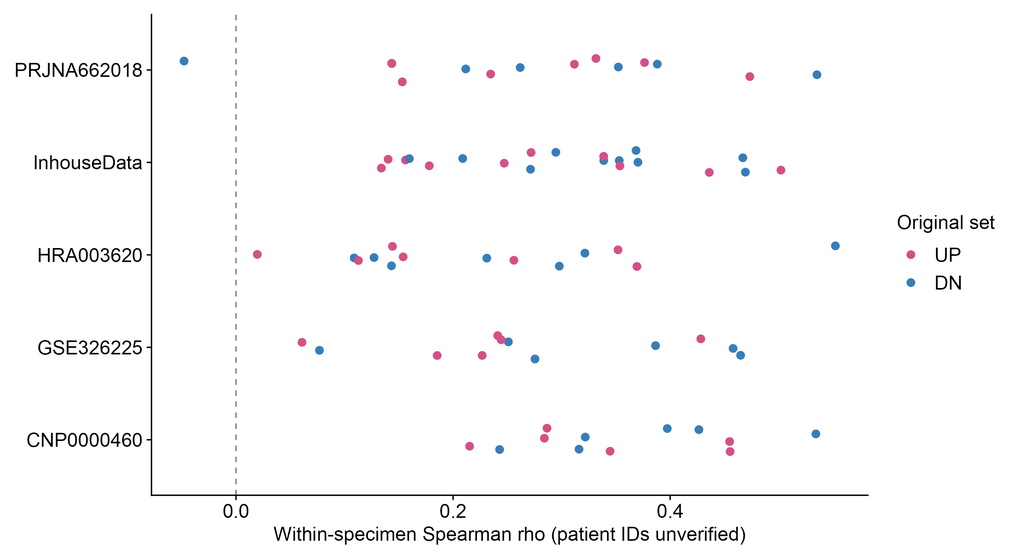

图A的可完成部分：每点一个肿瘤Epi样本内效应；不是患者效应。患者级图本轮因身份阻塞无法生成。 矢量 PDF

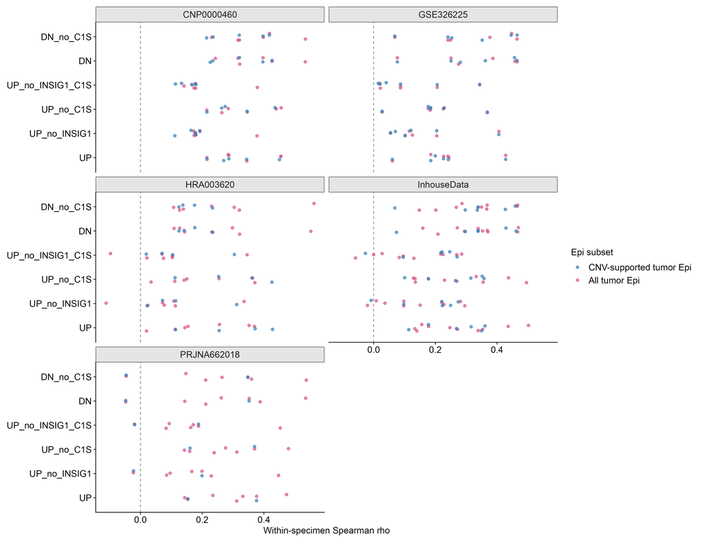

全部预设基因去除版本与既有CNV支持子集，保留所有可估计样本。没有患者级P值。 矢量 PDF

## 4. 独立耐药细胞模型 GSE171537

核实60个GSM/测定：253J、5637、KU1919、T24、TCCSUP各有parental、CisR、GemR、GemCisR及3个RNA采样。原文说明RNA来自三个不同传代；不能作为三次独立耐药诱导。GSM培养说明为取样前数代不加抗生素、顺铂或吉西他滨，采样为Untreated；未记录可独立拆分的测序批次。MP10发现数据的五个本地dataset不包含此队列，但无法证明未记录的历史筛选行为不存在。

| cell_line | comparison | parental | resistant_mean | delta |
| --- | --- | --- | --- | --- |
| 253J | CisR | 8.247 | 8.212 | -0.03449 |
| 5637 | CisR | 8.126 | 8.491 | 0.3642 |
| KU1919 | CisR | 8.264 | 8.128 | -0.1357 |
| T24 | CisR | 8.499 | 8.131 | -0.3677 |
| TCCSUP | CisR | 7.795 | 8.185 | 0.3903 |
| 253J | GemCisR | 8.247 | 8.111 | -0.1355 |
| 5637 | GemCisR | 8.126 | 8.243 | 0.1168 |
| KU1919 | GemCisR | 8.264 | 8.165 | -0.09833 |
| T24 | GemCisR | 8.499 | 8.352 | -0.1467 |
| TCCSUP | GemCisR | 7.795 | 8.383 | 0.5878 |
| 253J | GemR | 8.247 | 8.213 | -0.03419 |
| 5637 | GemR | 8.126 | 7.989 | -0.1374 |
| KU1919 | GemR | 8.264 | 8.063 | -0.2007 |
| T24 | GemR | 8.499 | 8.334 | -0.1647 |
| TCCSUP | GemR | 7.795 | 8.126 | 0.3306 |

| comparison | n_lines | n_positive | n_negative | n_zero | mean_delta | median_delta | CI_low | CI_high | P | FDR_3_comparisons |
| --- | --- | --- | --- | --- | --- | --- | --- | --- | --- | --- |
| CisR | 5 | 2 | 3 | 0 | 0.04333 | -0.03449 | -0.2083 | 0.2949 | 1 | 1 |
| GemCisR | 5 | 2 | 3 | 0 | 0.06482 | -0.09833 | -0.1325 | 0.3467 | 1 | 1 |
| GemR | 5 | 1 | 4 | 0 | -0.04128 | -0.1374 | -0.1737 | 0.1514 | 0.375 | 1 |

主要CisR−parental的五个背景效应分别为：253J −0.0345、5637 +0.3642、KU1919 −0.1357、T24 −0.3677、TCCSUP +0.3903。均值+0.0433，但中位数−0.0345，说明均值方向不能代表普遍升高。以完整细胞系背景等权bootstrap10000次，均值95%区间[−0.2083,0.2949]；双侧精确符号检验P=1。n=5下最小可能双侧P为0.0625，不能以P<0.05作成功门槛。

GemCisR也是2升3降，GemR为1升4降；三项比较共享亲本，并不独立。三项符号检验一起BH后的FDR均为1。差值是ssGSEA分数变化，不是基因表达fold change；n=5的bootstrap区间仅作探索描述，不能精确刻画所有BLCA模型的异质性。

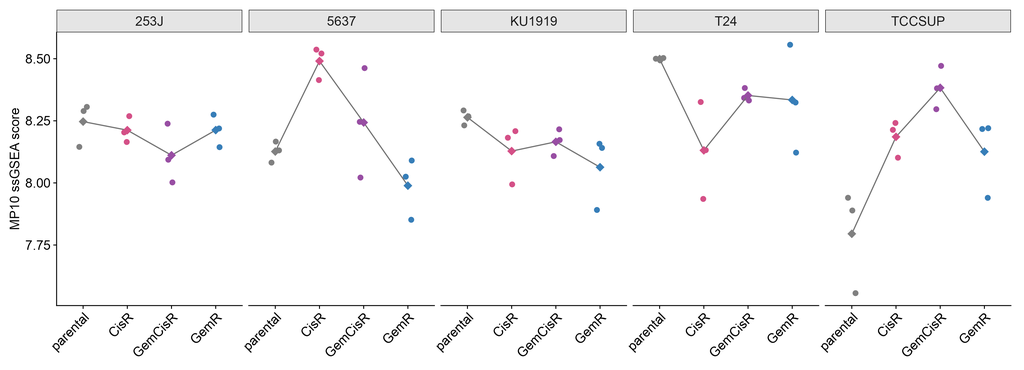

每个圆点为原始RNA传代采样，菱形为line×state均值；连接线只用于比较状态均值，不表示耐药演化轨迹。 矢量 PDF

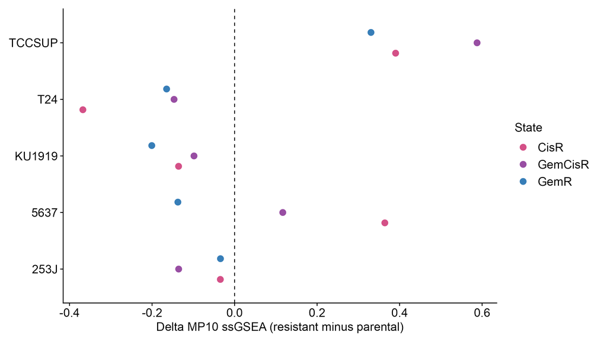

五个独立细胞系背景的全部预设差值，0线表示与亲本相同。 矢量 PDF

## 5. 临床：病理三态编码与独立建模

共同主终点为≤ypT1且ypN0；nonresponse=1表示未达到。严格pCR=ypT0N0为次要终点，non_pCR=1表示未达pCR。本项目预先固定这一顺序以便跨队列比较，即使GSE169455原文强调pCR也不交换主次。OR均为MP10每增加一个固定队列SD的效应，OR>1才是较差病理反应优势比升高。

### GSE212810

39个表达病例全部通过GSM、Case_#和作者患者编号连接到Table S6A；原标签21R/18NR完整保留，未用更大临床总体替代样本数。作者编码30 GP、5 ddMVAC、4 GCb；按原研究顺铂方案语境将GP归为gemcitabine/cisplatin，GCb为卡铂并严格排除，原始编码保留以便审核；未推断具体给药剂量。主入组35例，其中良好病理反应13、未反应15、未知7，实际主模型n=28。

作者S6A中777表示“无残余肿瘤”，0表示“非浸润或CIS”，999表示淋巴结未评估。7例ypN未知的作者R病例没有被静默算成良好反应；其中1例非浸润/CIS仍可明确排除pCR，因此pCR可评估n=29 (11 pCR、18非pCR)，未知6。原文NR句子中的ypN0与“淋巴结转移”矛盾，采用可追溯逐例病理，不机械照抄。两个作者表中2周期病例与GEO“至少3周期”总体说明不一致；主分析保留，≥3周期单独敏感性。

**共同主终点：OR=0.576，95% CI 0.217–1.526，P=0.267，预设临床家族保守BH(n=2) FDR=0.533。**未观察到较差病理反应方向；区间很宽，不能宣称保护作用。cT调整OR=0.508 (0.154–1.668)。含GCb全NAC可评估32例OR=0.689 (0.300–1.580)；≥3周期严格组n=26，OR=0.560 (0.207–1.512)。原作者R/NR全39例的独立补充分析OR=0.562 (0.248–1.274)，不替代病理三态终点。

pCR次要模型OR=0.530 (0.177–1.586)，P=0.256。cT调整模型触发稀疏/分离，按预设规则使用Firth的Jeffreys惩罚似然和profile区间：OR=0.687 (0.187–1.447)，P=0.371。估计方法没有按P值选择；本地实现已通过已知完全分离2×2数据的解析Firth OR=441数值核验，该单元测试从未混入科学分析数据。

### GSE169455

149个表达病例中125 NAC、24 induction，与GEO逐例字段一致。表达为治疗前TURB肿瘤；术后pTN在治疗后情境中重建ypTN。125 NAC均可判定共同主终点，54良好反应、71未反应；42 pCR、83非pCR。induction独立描述：23例共同终点可判定，1例pTCisNx为未知；该例可以排除pCR，故induction的pCR n=24。病理解析覆盖IS/CIS、a/b后缀及Nx，相关修正有留痕。

**严格顺铂主分析仍BLOCKED：**GEO不含逐例方案和周期；出版社/preprint补充材料多次403/401，后续原作者开放补充表为基因统计，未给出可与GSM连接的方案表。系列总体“cisplatin-based”描述没有替代逐例审计。作为明确降级的125例NAC方案未核实补充分析，OR=0.767 (0.533–1.104)，P=0.154；cT调整0.811 (0.553–1.191)，亚型调整0.801 (0.542–1.185)。这些结果不能标成严格顺铂独立验证。

pCR补充分析OR=0.776 (0.531–1.134)，P=0.191；induction共同终点OR=1.133 (0.426–3.011)，与NAC点估计方向不同但区间宽。没有按最显著亚型筛选结果，也没有进行足以断言亚型交互的分层推断。方案、周期、实际肿瘤含量调整受数据限制；微切割/宏切割不能视为100%肿瘤纯度，没有做“评分除以纯度”。

### 固定标准化与全部模型

| cohort | n_scale | mean | SD | scale_population |
| --- | --- | --- | --- | --- |
| GSE169455 | 125 | 0.6675 | 0.1874 | NAC_individual_regimen_unknown_fallback |
| GSE212810 | 35 | 0.8426 | 0.1736 | strict_cisplatin_NAC |

每队列只使用一次固定均值和样本SD。GSE212810在35例顺铂方案入组者中标准化，同一z用于28/29例不同终点及含GCb补充模型；GSE169455在125例NAC中标准化，induction沿用此参考尺度。没有按R/NR分别标准化。所有P双侧，主模型为未调整logistic；下表保留实际n、事件、缺失和估计方法。

| cohort | scope | endpoint | adjustment | n_enrolled | n | events | missing | OR | CI_low | CI_high | P | FDR | method |
| --- | --- | --- | --- | --- | --- | --- | --- | --- | --- | --- | --- | --- | --- |
| GSE169455 | NAC_regimen_unverified_sensitivity | nonresponse | none | 125 | 125 | 71 | 0 | 0.7674 | 0.5335 | 1.104 | 0.1537 | NA | glm_logit_Wald |
| GSE169455 | NAC_regimen_unverified_sensitivity | nonresponse | cT | 125 | 125 | 71 | 0 | 0.8114 | 0.5527 | 1.191 | 0.2862 | NA | glm_logit_Wald |
| GSE169455 | NAC_regimen_unverified_sensitivity | nonresponse | subtype | 125 | 125 | 71 | 0 | 0.8012 | 0.5417 | 1.185 | 0.267 | NA | glm_logit_Wald |
| GSE169455 | NAC_regimen_unverified_sensitivity | non_pCR | none | 125 | 125 | 83 | 0 | 0.7762 | 0.5311 | 1.134 | 0.1907 | NA | glm_logit_Wald |
| GSE169455 | NAC_regimen_unverified_sensitivity | non_pCR | cT | 125 | 125 | 83 | 0 | 0.8293 | 0.5494 | 1.252 | 0.3729 | NA | glm_logit_Wald |
| GSE169455 | NAC_regimen_unverified_sensitivity | non_pCR | subtype | 125 | 125 | 83 | 0 | 0.8393 | 0.5586 | 1.261 | 0.3991 | NA | glm_logit_Wald |
| GSE169455 | induction_separate_descriptive | nonresponse | none | 24 | 23 | 16 | 1 | 1.133 | 0.4263 | 3.011 | 0.8023 | NA | glm_logit_Wald |
| GSE169455 | induction_separate_descriptive | non_pCR | none | 24 | 24 | 18 | 0 | 0.7429 | 0.2593 | 2.128 | 0.5799 | NA | glm_logit_Wald |
| GSE212810 | strict_cisplatin_NAC | nonresponse | none | 35 | 28 | 15 | 7 | 0.5756 | 0.2172 | 1.525 | 0.2667 | 0.5334 | glm_logit_Wald |
| GSE212810 | strict_cisplatin_NAC | nonresponse | cT | 35 | 28 | 15 | 7 | 0.5075 | 0.1544 | 1.668 | 0.2639 | NA | glm_logit_Wald |
| GSE212810 | all_NAC_including_GCb_sensitivity | nonresponse | none | 39 | 32 | 18 | 7 | 0.6885 | 0.3001 | 1.58 | 0.3784 | NA | glm_logit_Wald |
| GSE212810 | strict_cisplatin_cycles_ge3_sensitivity | nonresponse | none | 33 | 26 | 13 | 7 | 0.56 | 0.2074 | 1.512 | 0.2526 | NA | glm_logit_Wald |
| GSE212810 | strict_cisplatin_NAC | non_pCR | none | 35 | 29 | 18 | 6 | 0.5298 | 0.177 | 1.586 | 0.2561 | 0.5122 | glm_logit_Wald |
| GSE212810 | strict_cisplatin_NAC | non_pCR | cT | 35 | 29 | 18 | 6 | 0.6869 | 0.1866 | 1.447 | 0.3711 | NA | Firth_Jeffreys_profile_likelihood |
| GSE212810 | all_NAC_including_GCb_sensitivity | non_pCR | none | 39 | 33 | 22 | 6 | 0.6484 | 0.2535 | 1.658 | 0.3659 | NA | glm_logit_Wald |
| GSE212810 | strict_cisplatin_cycles_ge3_sensitivity | non_pCR | none | 33 | 27 | 16 | 6 | 0.5233 | 0.1722 | 1.591 | 0.2536 | NA | glm_logit_Wald |
| GSE212810 | author_NAC_labels_supplementary | author_nonresponse | none | 39 | 39 | 18 | 0 | 0.5616 | 0.2476 | 1.274 | 0.1674 | NA | glm_logit_Wald |
| GSE169455 | strict_cisplatin_NAC | nonresponse | none | 0 | 0 | NA | 125 | NA | NA | NA | NA | NA | BLOCKED |

临床主FDR家族预设两队列：仅GSE212810严格分析可估计，保留总家族大小2进行保守BH，GSE169455缺失项保持NA；不将方案未核实敏感性偷偷换成主检验。pCR另列次要家族；敏感性不作显著性菜单。没有合并两队列OR。

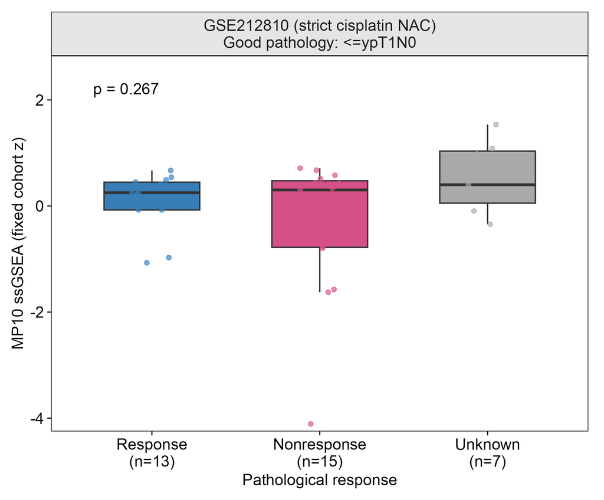

严格顺铂方案入组35例，每患者一个点；未知7例单独显示。P来自28例可评估者的连续logistic模型，不是图中三组检验。 矢量 PDF

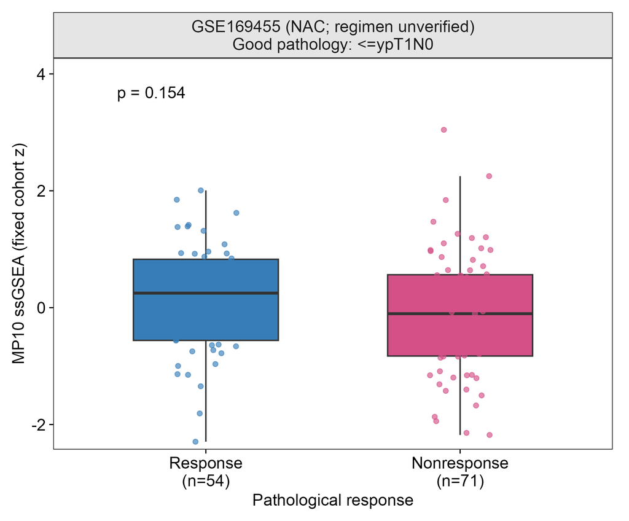

125例NAC方案未核实的补充分布，不能称为严格顺铂主验证。P来自连续logistic模型。 矢量 PDF

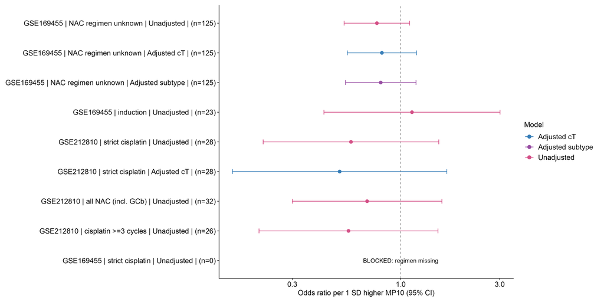

共同主终点及预设调整/敏感性分别标注；严格GSE169455主结果保留BLOCKED。 矢量 PDF

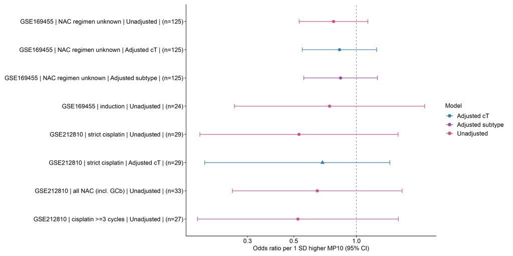

严格pCR为独立次要终点；三角点使用触发后的Firth profile推断。 矢量 PDF

## 6. 不一致、解释边界与下一步

跨层级不一致是本轮最重要的发现：Epi中UP正相关，但DN同样正相关；去共享INSIG1后UP明显衰减。细胞系升降混合，5637/TCCSUP升高而T24/KU1919/253J下降。临床两个可分析NAC人群点估计偏向OR<1，induction点估计偏向OR>1，均无精确证据；不是“独立临床验证成功”。患者间异质性目前无法独立估计，样本差异不能伪称患者差异。

MP10涉及甲羟戊酸/胆固醇相关转录过程，但表达不直接等于胆固醇含量或通量，不能证明胆固醇本身导致耐药。单臂NAC病理反应关联不能等同获得性耐药；没有治疗比较及交互分析，不能宣称预测顺铂治疗获益。临床bulk还混有组成因素，Epi统计层级与bulk也不同。

1. **优先补齐低成本关键审计资料：**Epi样本到确认患者ID的交叉表及既有细胞周期分数；GSE169455逐例方案/混合换药/周期表。补齐后仍按当前冻结主终点与Top20重算，不改方向和阈值。
2. **暂降低“普适顺铂耐药MP10”的机制投入优先级。**当前不能以大规模TME/空间关联扩展来补救不一致的耐药证据。
3. 若继续功能验证，优先在升高的5637或TCCSUP和下降的T24/KU1919各选背景，测真实顺铂剂量反应并设计独立诱导/培养重复；结合通路干预、救援及胆固醇/甲羟戊酸通量测量，检验背景依赖而非预设普遍方向。此为下一步建议，本轮未实施。

## 7. 阻塞项、可复现性与交付入口

| module | status | reason | minimum_needed | completed |
| --- | --- | --- | --- | --- |
| 01_epi_patient_inference | BLOCKED | 57 specimens: 37 derived,20 provisional patient IDs; original-to-local crosswalk not independently verified | sample_uid to confirmed patient_id with evidence; track multiple specimens | 123699 per-cell scores; all six gene-set variants; tumor/normal/CNV specimen effects |
| 01_epi_adjusted | BLOCKED | S.Score and G2M.Score absent in small metadata/cache | cell_id matched existing S.Score and G2M.Score with computation provenance | nCount_RNA/nFeature_RNA available; adjustment remains NA, no depth-only substitute |
| 03_GSE169455_strict | BLOCKED | individual regimen/cycles unavailable from GEO; original publisher supplements/preprint access failed; later author material did not supply joined clinical case table | GSM or BLCA_Cx/BLCA_Nac ID joined to cisplatin/carboplatin regimen, mixed/switch details and cycles | all149 scored;125 NAC and24 induction separated; real ypTN reconstructed;125 NAC sensitivity models |
| clinical_tumor_content | BLOCKED | no patient matched actual tumor percentage | pretreatment pathological tumor content | no purity division/inference substituted |
| GSE87304_conditional_extension | NOT_ADMITTED | series305 pre-NAC verified; sampled GSM clinical metadata lacks regimen and postoperative ypTN; no verified outcome crosswalk obtained | GSM/patient/regimen/ypTN crosswalk | official series and sample audit; no OS proxy; no6GB CEL download |

GSE87304仅审计系列与样本：305例pre-NAC/TURBT说明可核实，但抽查GSM无逐例方案或术后ypTN，没有获得可追溯患者终点表，故未满足条件扩展纳入；未下载6GB CEL，更未用OS代替疗效。

**77项风险相关检查全部通过；7张核心表完整重跑hash一致。**全流程各步骤退出码0，最高实测RSS为4.95 GiB，最多2个data.table线程、BLAS/OMP1线程，重跑入口设12GiB虚拟内存上限，远低于48CPU/200GB上限。没有加载完整Seurat、复制大对象或构建全细胞排名矩阵。无需大任务或调度器，未提交任何job。用户23:00–07:00 Asia/Shanghai限制用于大任务；本轮完成的是低资源小任务。

| step | peak_RSS_KiB | exit_status | log |
| --- | --- | --- | --- |
| 03_epi_mapping | 999084 | 0 | logs/replay_20261109T225128/03_epi_mapping.log |
| 06_figures | 1311336 | 0 | logs/replay_20261109T225128/06_figures.log |
| 02_bulk_scores | 1644540 | 0 | logs/replay_20261109T225128/02_bulk_scores.log |
| 01_prepare | 416724 | 0 | logs/replay_20261109T225128/01_prepare.log |
| 00_extract_clinical | 83796 | 0 | logs/replay_20261109T225128/00_extract_clinical.log |
| 05_models | 1014160 | 0 | logs/replay_20261109T225128/05_models.log |
| 04b_patient_summary | 173748 | 0 | logs/replay_20261109T225128/04b_patient_summary.log |
| 04_epi | 5191504 | 0 | logs/replay_20261109T225128/04_epi.log |

图件为白底300dpi PNG及矢量PDF、真实Arial约12pt、线宽≥1pt。有图例的图同时给出panel_only/legend_only PDF。配对与森林图无现成技能模板，采用统一主题和导出器单独实现。图A患者级版未伪造，以准确标注的样本描述图提供可完成部分。报告内图片嵌入，可离线独立阅读。

- 完整重跑入口；执行：`bash '/home/data/t070721/codex_workspace/Bladder Metabolism/results/mp10_resistance_validation_v1/scripts/run_all.sh'`。
- 冻结公共输入核验/缺失时恢复；上游hash改变将停止，不自动覆盖。
- 公共来源与hash；本地输入及原对象路径；解析/Firth修订记录。
- Epi细胞分数；全部样本原始/敏感性效应；患者级BLOCKED/NA。
- 细胞系GSM映射；line×state分数；配对差值。
- 临床逐患者入组/终点审计；全部临床模型；模型实际患者使用清单。
- 跨模块证据汇总；图件索引；验收检查；重跑hash比对；R sessionInfo。

## 8. 原始来源

- [MSigDB UP](https://www.gsea-msigdb.org/gsea/msigdb/human/geneset/TSUNODA_CISPLATIN_RESISTANCE_UP.html)、[DN](https://www.gsea-msigdb.org/gsea/msigdb/human/geneset/TSUNODA_CISPLATIN_RESISTANCE_DN.html)；[Tsunoda Table1](https://www.nature.com/articles/1208313/tables/1)、[Table2](https://www.nature.com/articles/1208313/tables/2)。
- GSE171537、[原论文与RNA传代说明](https://pmc.ncbi.nlm.nih.gov/articles/PMC11094426/)。
- GSE169455、[Sjödahl等原研究](https://doi.org/10.1016/j.eururo.2021.10.035)。
- GSE212810、[原论文及Table S6A](https://pmc.ncbi.nlm.nih.gov/articles/PMC10591055/)，本地原始附件为00_audit/sources/mmc9.xlsx。